# Final Project

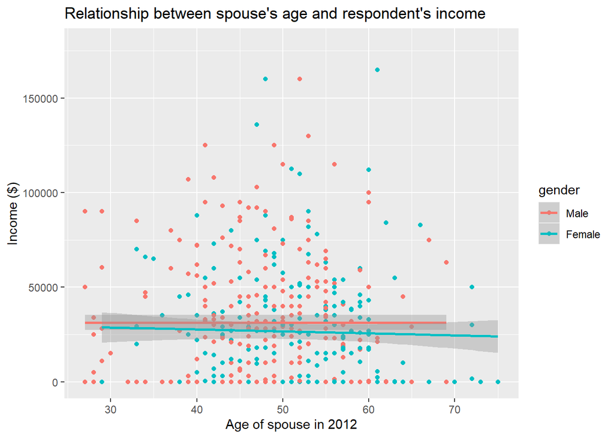

**(f)** Education

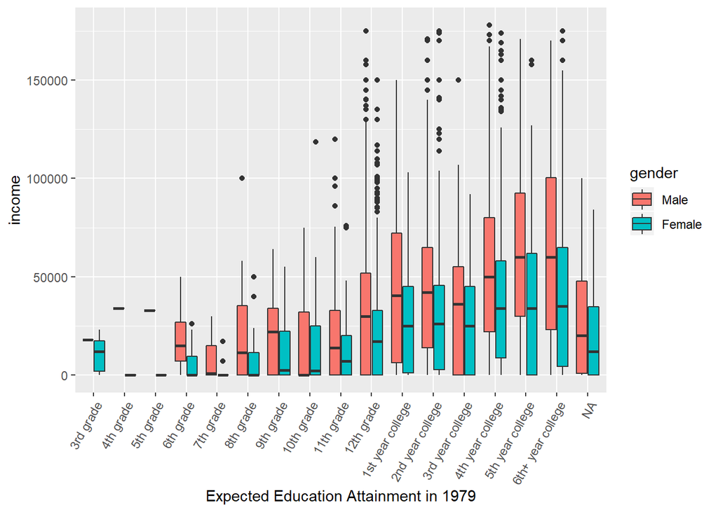

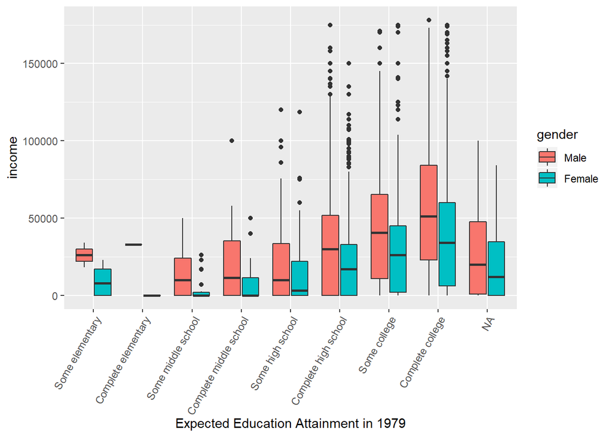

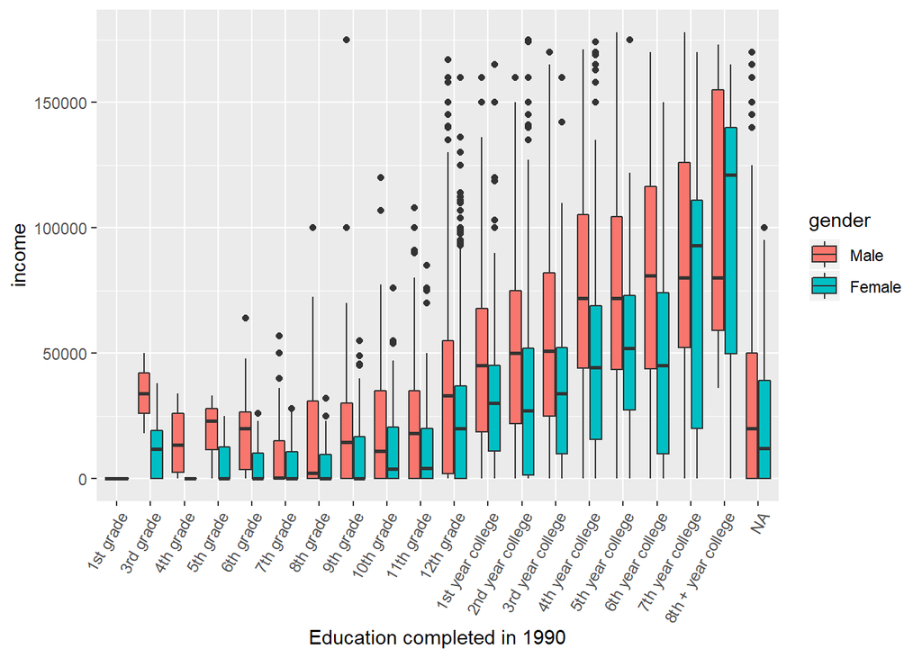

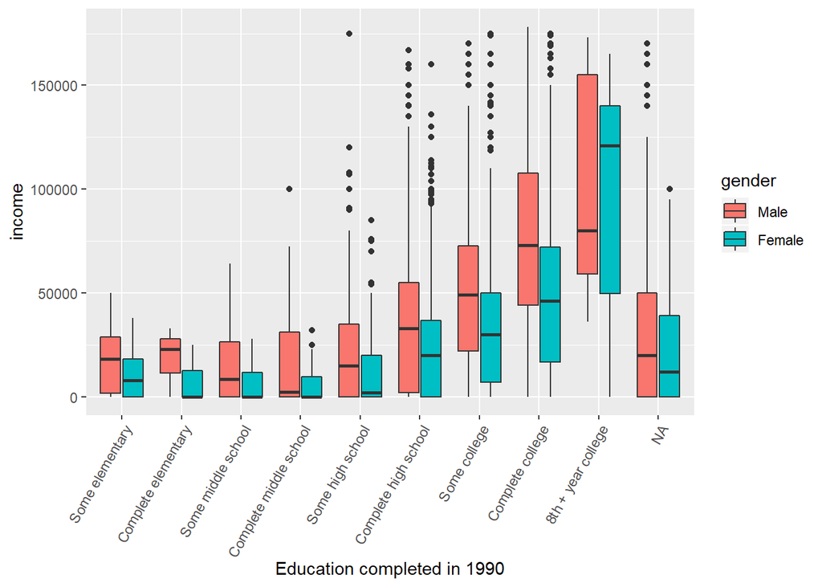

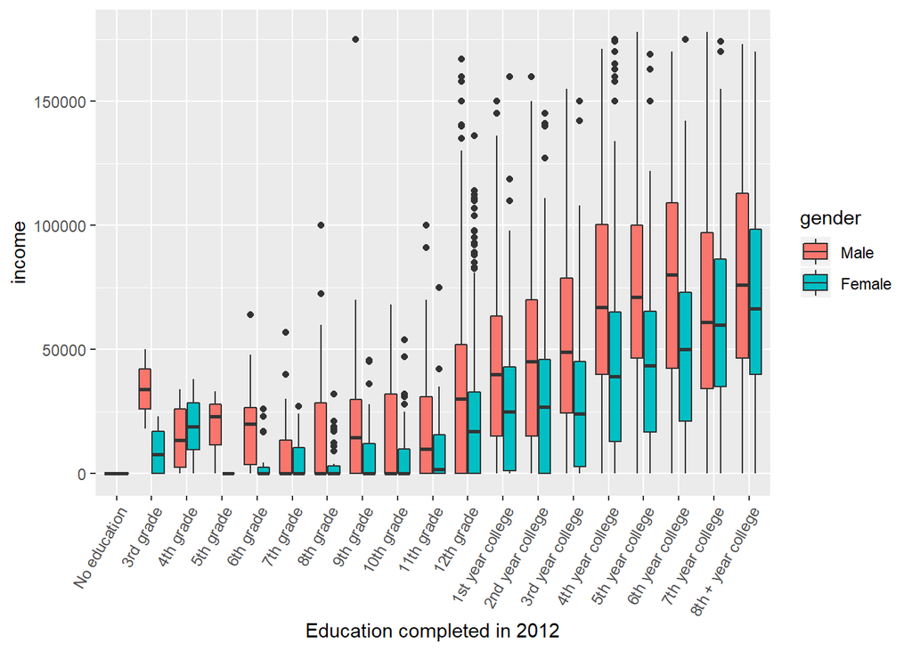

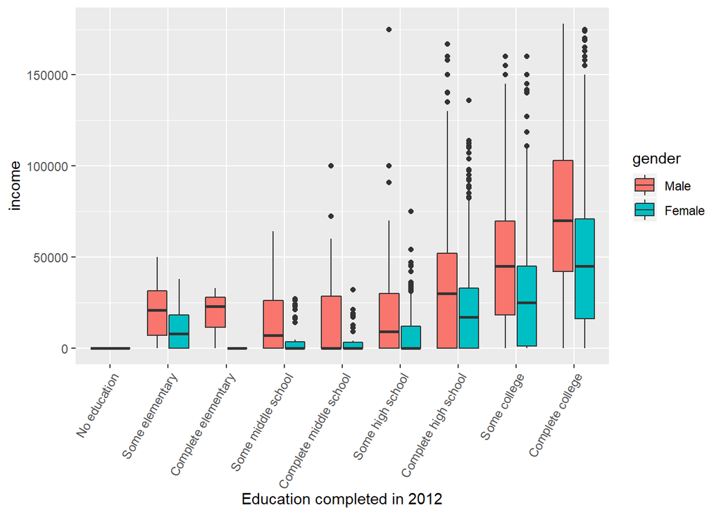

**(g)** Work Experience, Ambitions, Income

```
## # A tibble: 2 x 5
##   veteran     income.gap  upper  lower is.significant
##   <fct>            <dbl>  <dbl>  <dbl>          <dbl>
## 1 Not veteran     13789. 11603. 15975.              1
## 2 Veteran         17847.  5861. 29833.              1
```

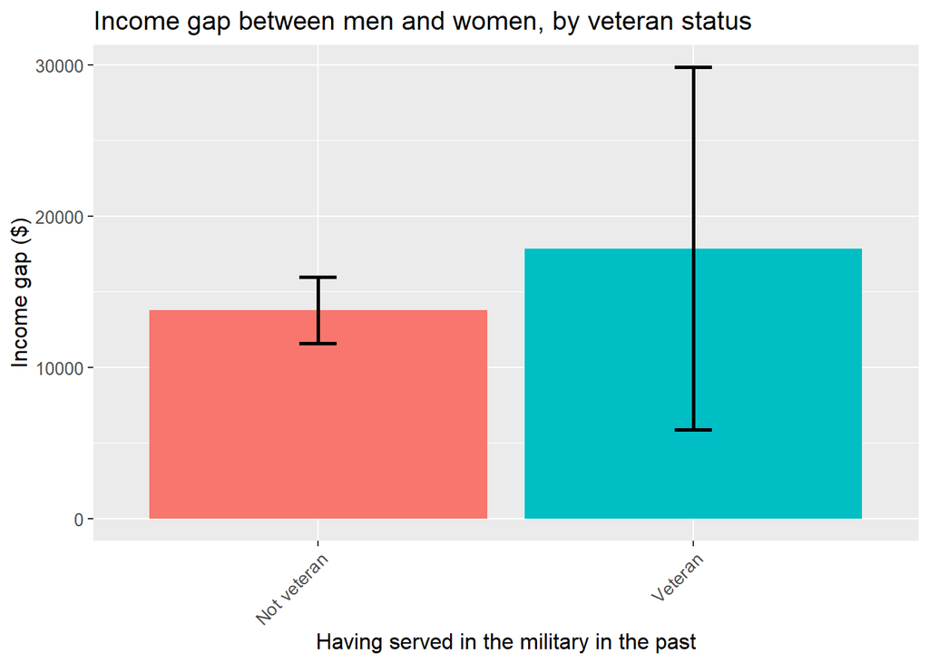

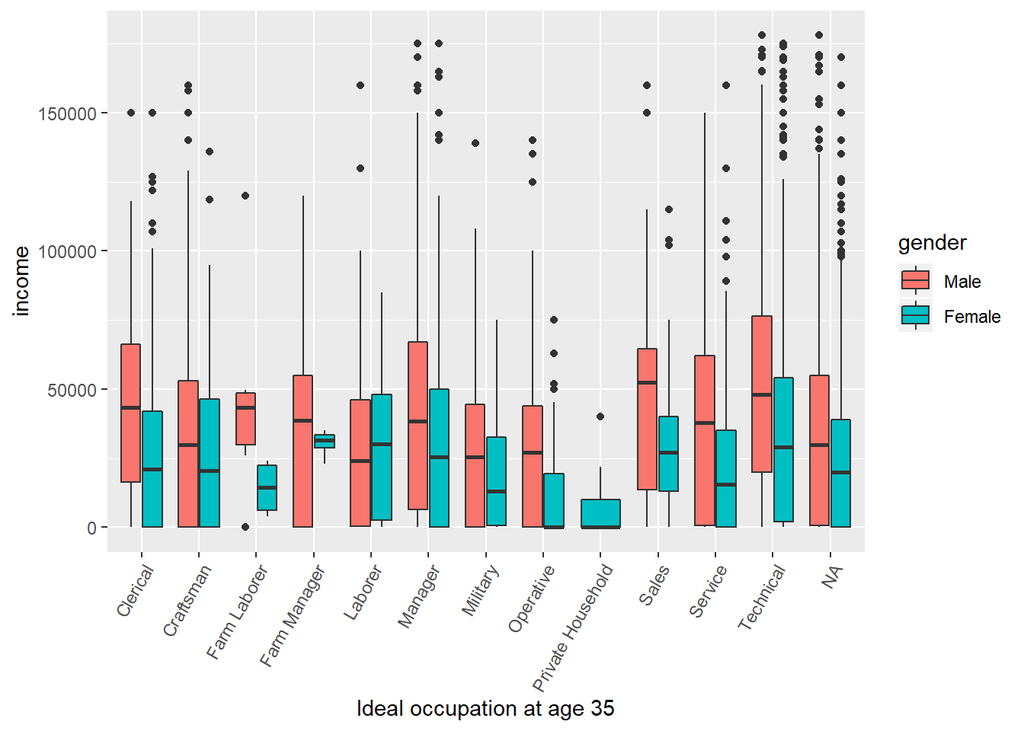

```
## # A tibble: 2 x 5
##   schoolin5years income.gap  upper  lower is.significant
##   <fct>               <dbl>  <dbl>  <dbl>          <dbl>
## 1 No                 13128. 11068. 15189.              1
## 2 Yes                14070. 11216. 16923.              1
```

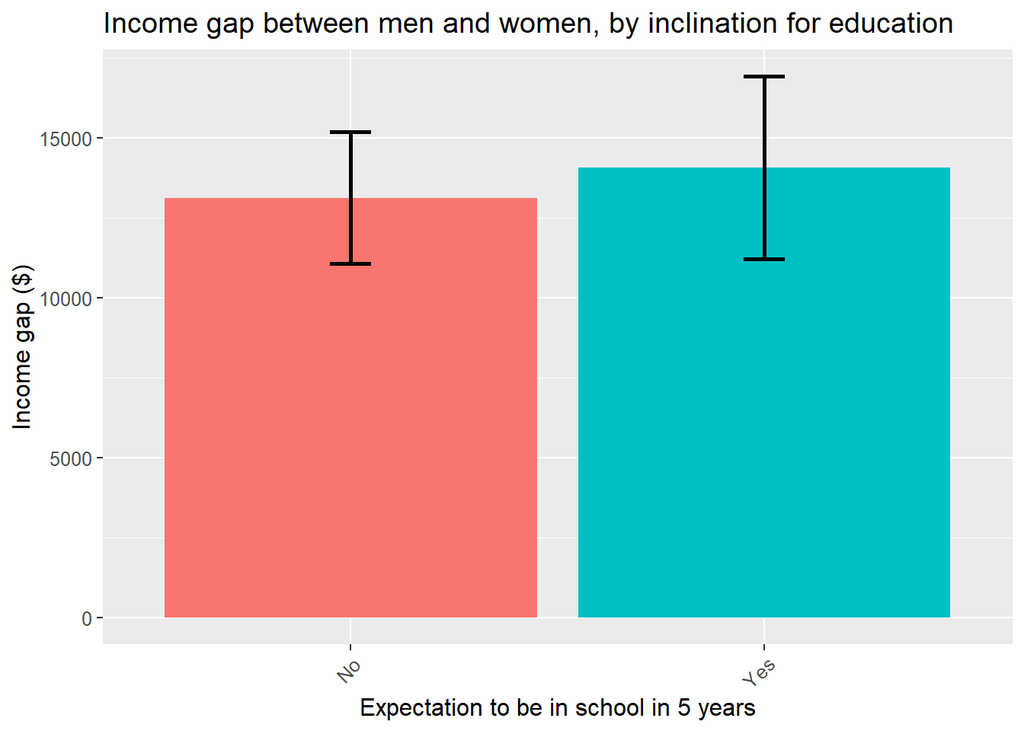

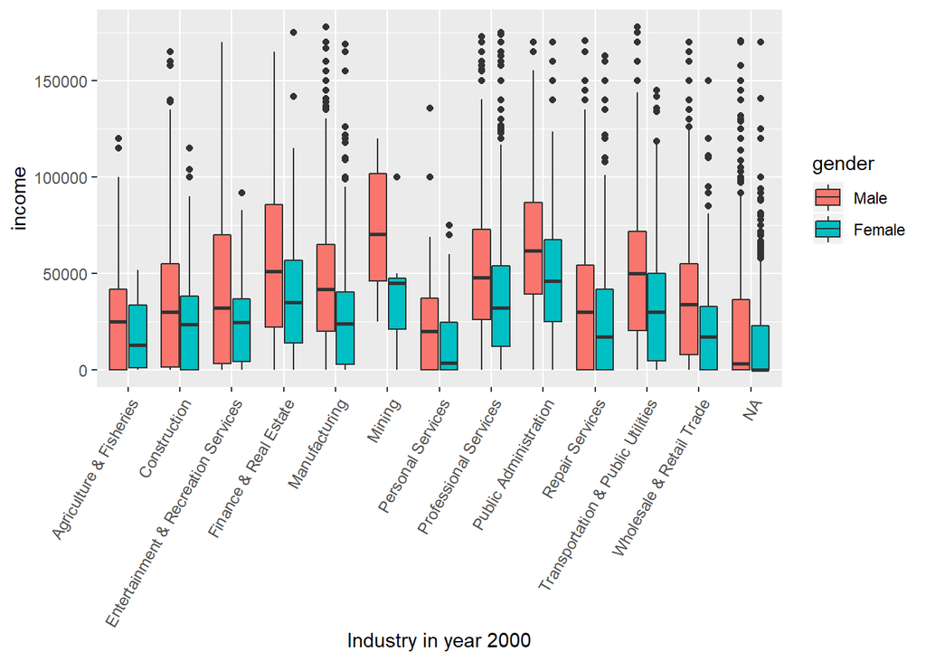

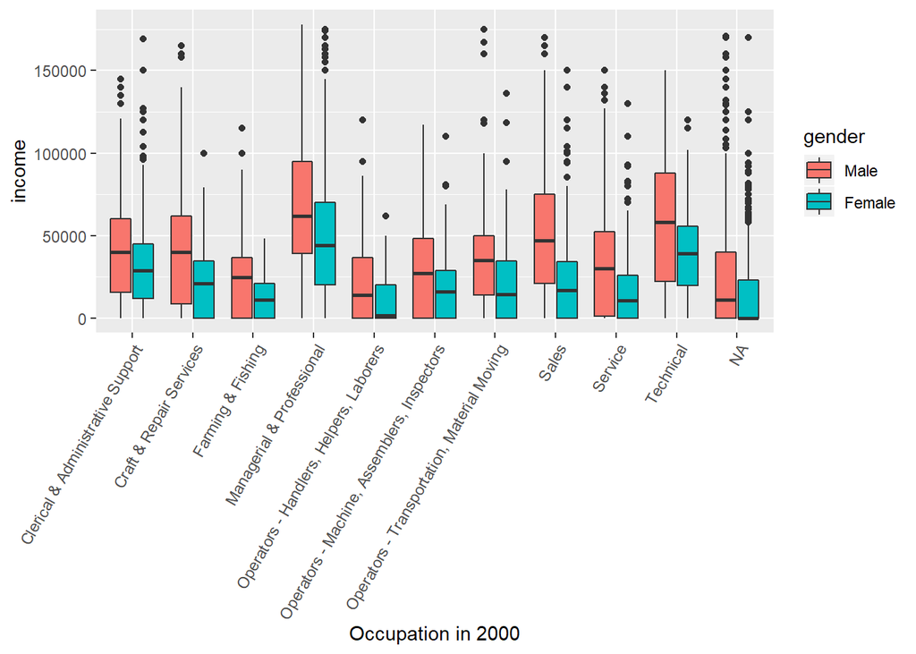

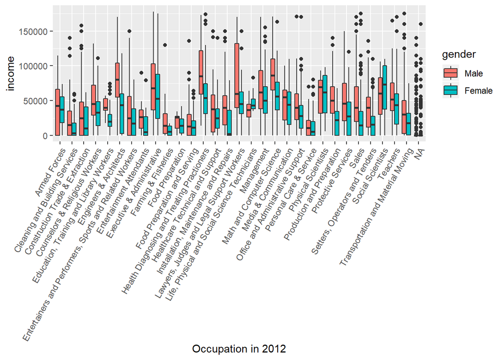

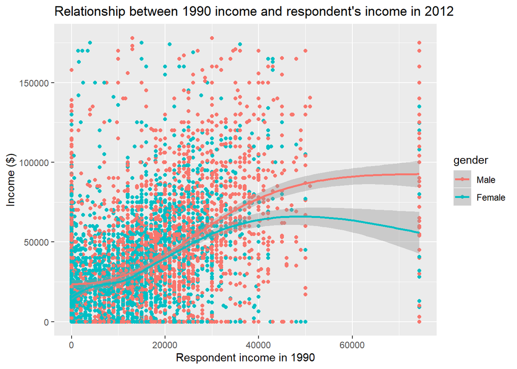

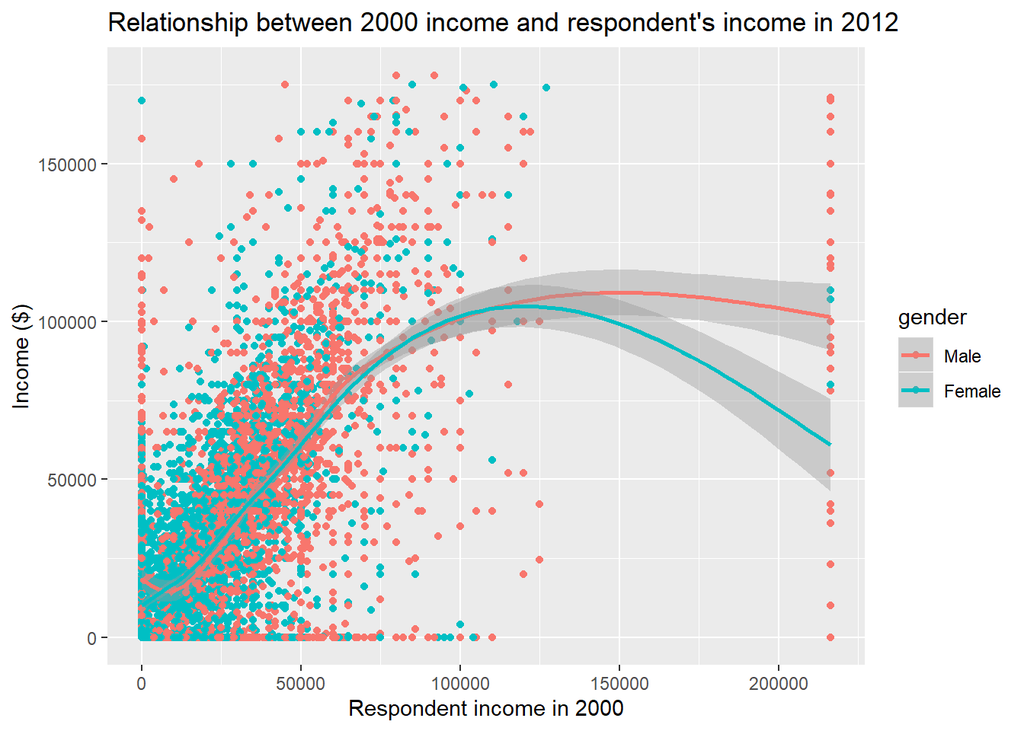

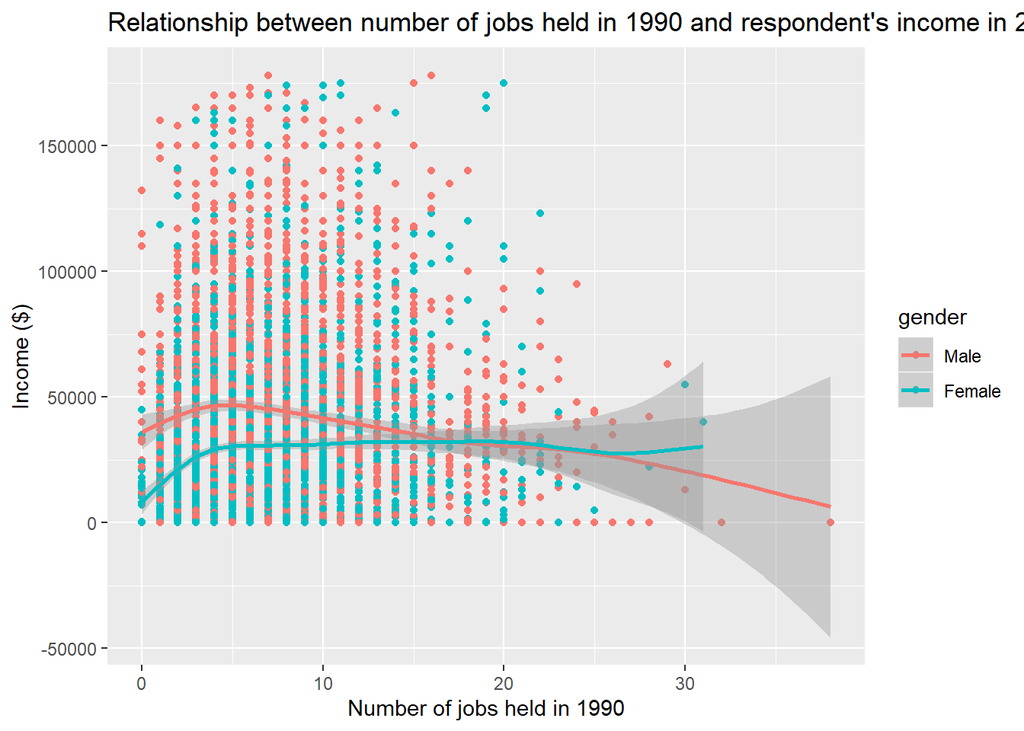

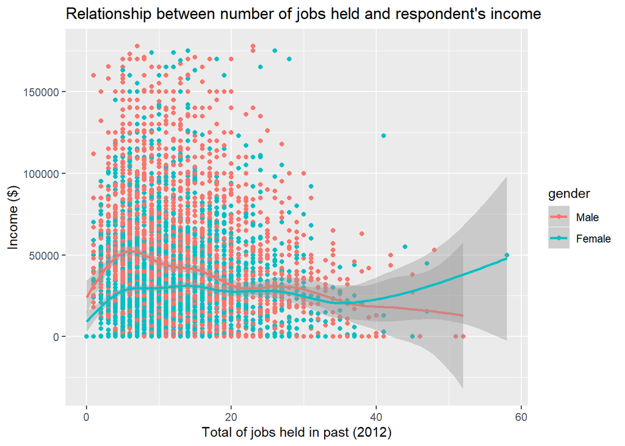

**(h)** Values

```
## # A tibble: 4 x 5
##   fa.womenathome income.gap  upper  lower is.significant
##            <dbl>      <dbl>  <dbl>  <dbl>          <dbl>
## 1              1     13871.  9807. 17936.              1
## 2              2     16569. 14220. 18917.              1
## 3              3     17950. 14346. 21553.              1
## 4              4     12967.  7783. 18150.              1
```

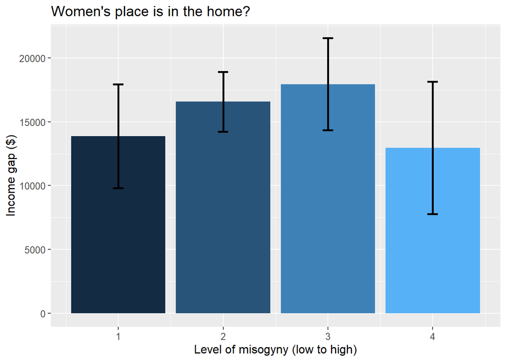

```
## # A tibble: 4 x 5
##   fa.notimetowork income.gap  upper  lower is.significant
##             <dbl>      <dbl>  <dbl>  <dbl>          <dbl>
## 1               1     12248.  5996. 18500.              1
## 2               2     15258. 13010. 17507.              1
## 3               3     15169. 12149. 18188.              1
## 4               4     15742. 10339. 21145.              1
```

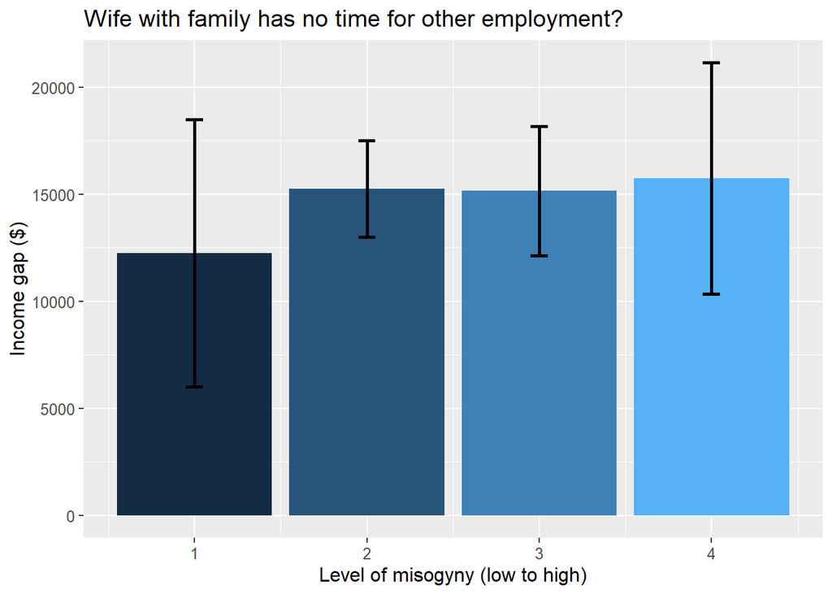

```
## # A tibble: 4 x 5
##   fa.proworkwife income.gap  upper  lower is.significant
##   <fct>               <dbl>  <dbl>  <dbl>          <dbl>
## 1 1                  11027.  6615. 15439.              1
## 2 2                  15349. 13094. 17605.              1
## 3 3                  11347.  8151. 14543.              1
## 4 4                  11425.  2314. 20535.              1
```

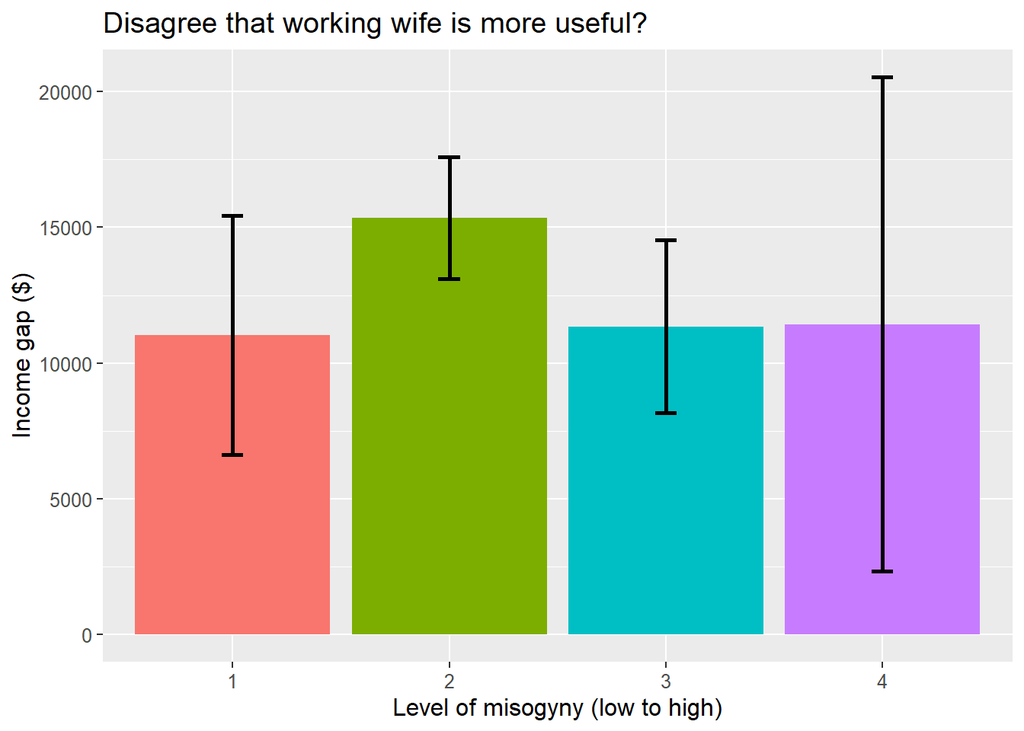

```
## # A tibble: 4 x 5
##   fa.badchildren income.gap  upper  lower is.significant
##            <dbl>      <dbl>  <dbl>  <dbl>          <dbl>
## 1              1     12485.  8009. 16960.              1
## 2              2     12324. 10066. 14583.              1
## 3              3     18881. 15542. 22219.              1
## 4              4     16268. 10024. 22511.              1
```

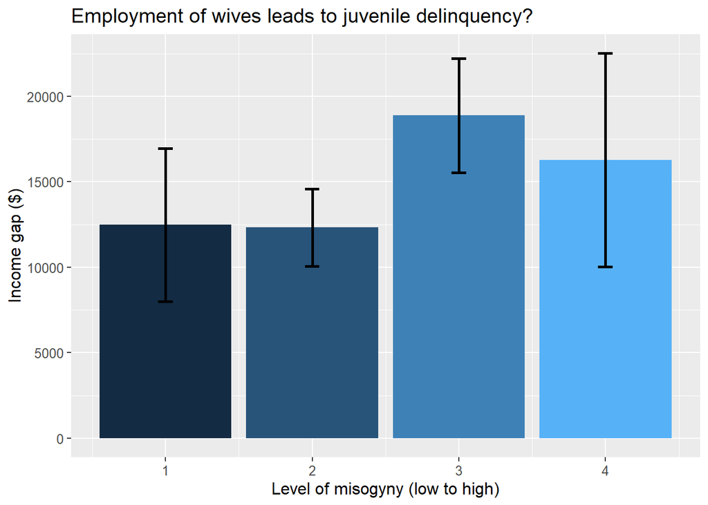

```
## # A tibble: 4 x 5
##   fa.genderrole income.gap  upper  lower is.significant
##           <dbl>      <dbl>  <dbl>  <dbl>          <dbl>
## 1             1     10526.  4236. 16817.              1
## 2             2     15843. 13211. 18475.              1
## 3             3     16003. 13365. 18640.              1
## 4             4     11726.  7555. 15896.              1
```

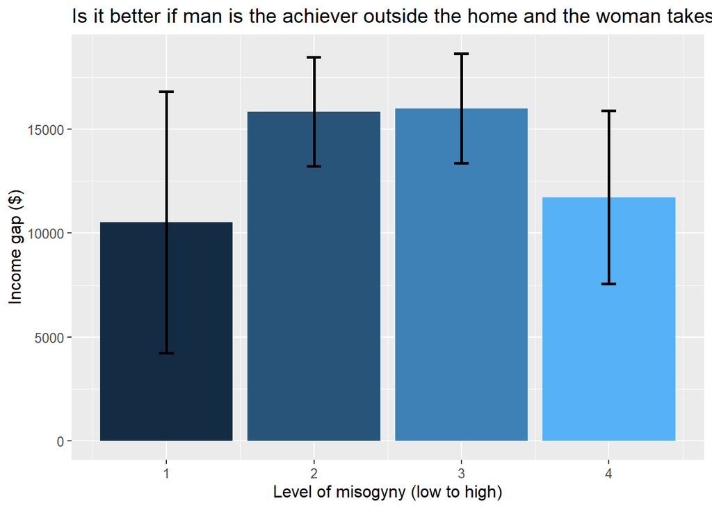

```
## # A tibble: 4 x 5
##   fa.menhousework income.gap  upper  lower is.significant
##   <fct>                <dbl>  <dbl>  <dbl>          <dbl>
## 1 1                   12157.  8446. 15867.              1
## 2 2                   14829. 12584. 17074.              1
## 3 3                   14225. 10281. 18169.              1
## 4 4                   14275.  7060. 21491.              1
```

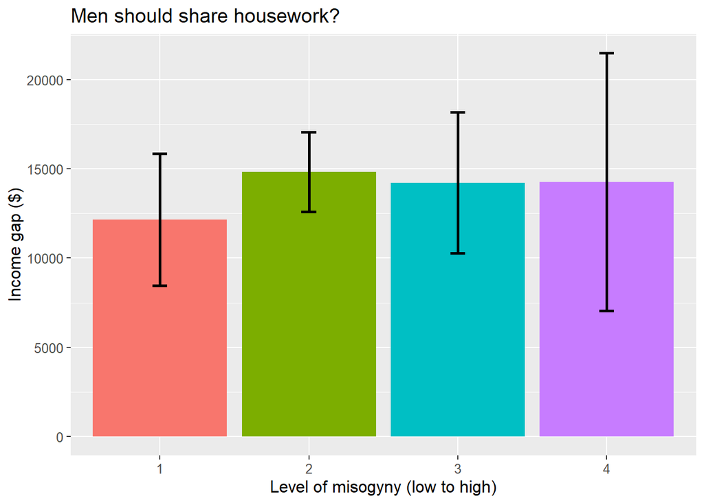

```
## # A tibble: 4 x 5
##   fa.happytradrole income.gap  upper  lower is.significant
##              <dbl>      <dbl>  <dbl>  <dbl>          <dbl>
## 1                1     13987.  7999. 19975.              1
## 2                2     16463. 14081. 18846.              1
## 3                3     12719.  9975. 15463.              1
## 4                4      9623.  4399. 14848.              1
```

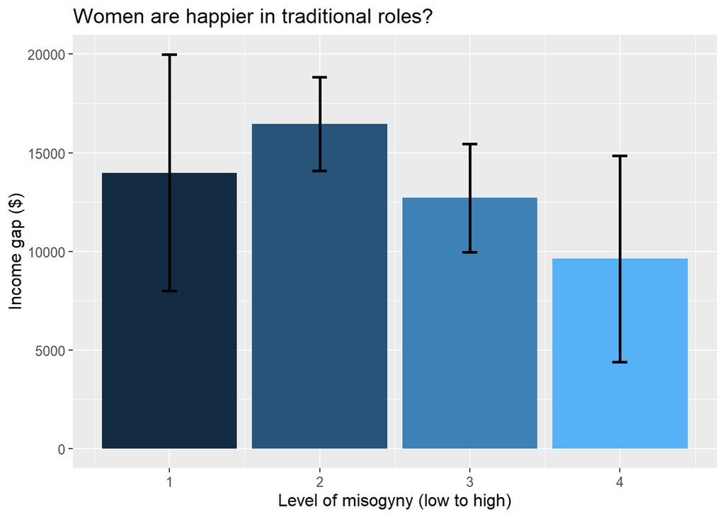

**(i)** Criminal History and Substance Use

```
## # A tibble: 2 x 5
##   crime.charge  income.gap  upper  lower is.significant
##   <fct>              <dbl>  <dbl>  <dbl>          <dbl>
## 1 Never charged     15269. 13465. 17073.              1
## 2 Charged            6865.   905. 12826.              1
```

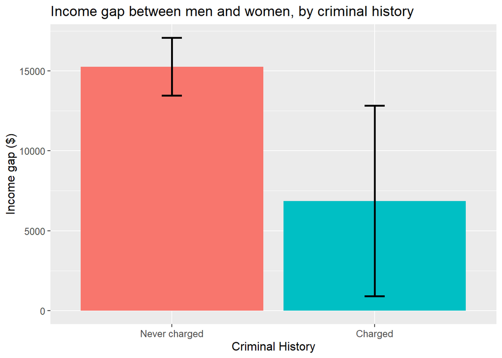

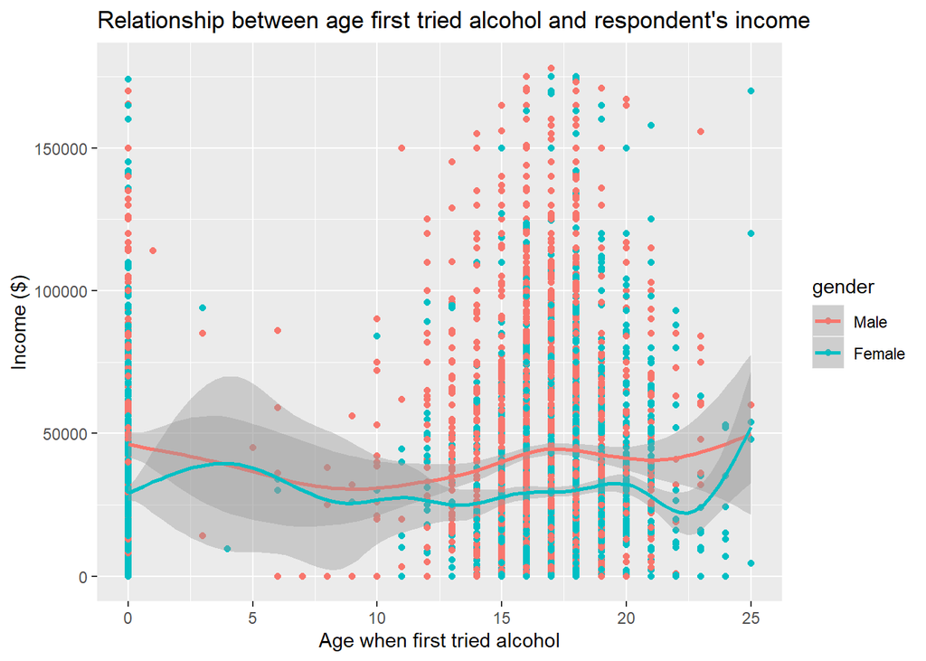

```
## # A tibble: 6 x 5
##   marijuana income.gap  upper  lower is.significant
##       <dbl>      <dbl>  <dbl>  <dbl>          <dbl>
## 1         0     15830. 13086. 18573.              1
## 2         1     13298.  9999. 16598.              1
## 3         2     13023.  7477. 18568.              1
## 4         3     10704.  4430. 16977.              1
## 5         4     16339. 10741. 21936.              1
## 6         5      5852.  -903. 12607.              0
```

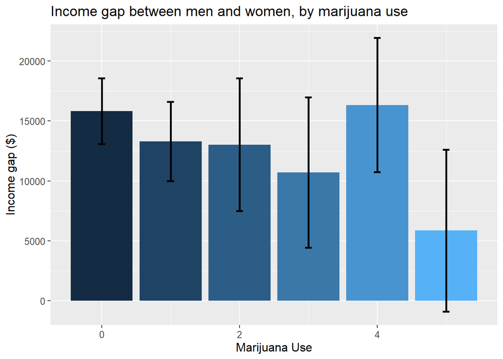

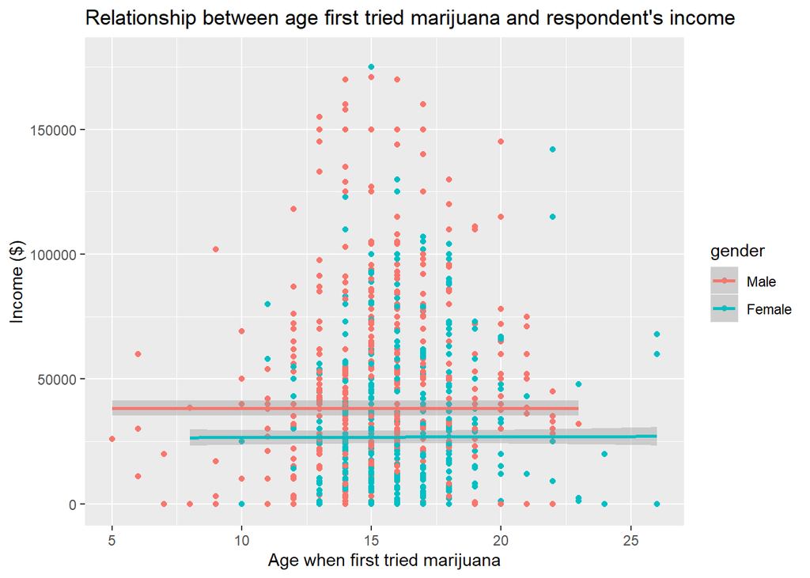

```
## # A tibble: 9 x 5
##   cocaine1990       income.gap   upper  lower is.significant
##   <fct>                  <dbl>   <dbl>  <dbl>          <dbl>
## 1 Never                 15861.  13867. 17855.              1
## 2 1-2 times              8883.   1848. 15917.              1
## 3 3-5 times             17868.   9159. 26577.              1
## 4 6-10 times             6161.  -4195. 16518.              0
## 5 11-49 times           16672.   8798. 24545.              1
## 6 50-99 times            4190.  -8639. 17019.              0
## 7 100 or more times      4964.  -3475. 13404.              0
## 8 Refuse to answer       8883. -11976. 29741.              0
## 9 I don't know         -33333. -91497. 24830.              0
```

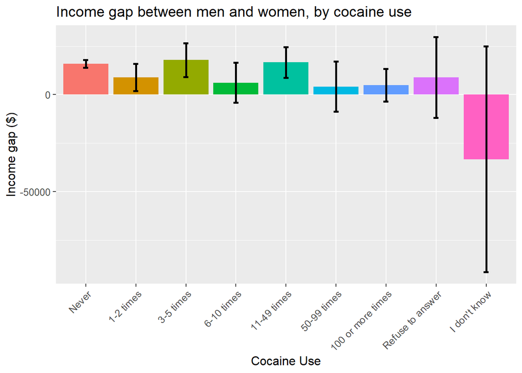

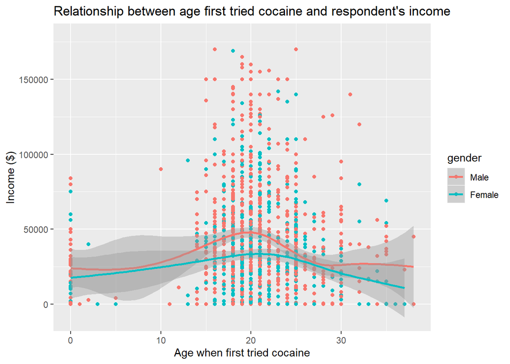

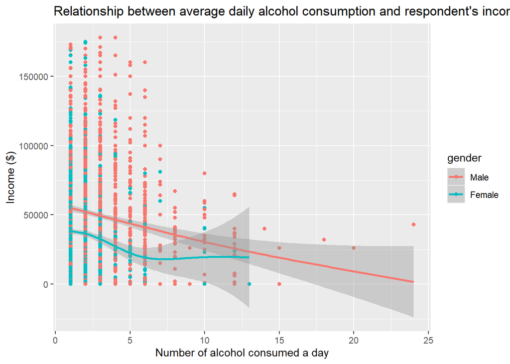

### **(2)** Methodology

- race (`race`)
- childhood poverty (`poverty1990`)
- recent marital status (`maritalc.status2000`)
- early career income (`income1990`)
- spouse’s work (`spouse.workhours2012`)
- education level (`edu.completedin2012`)

The missing values were coded as NA and were left out of the analysis. This led to sometimes having too few data points, or an highly unequal proportion of men or women to have meaningful analyse of the data using t-tests. Since we are limiting ourselves to respondents who have recorded values for their 2012 income, many were too young to have participated in the survey in 1979. Therefore, there were more missing values from the earlier survey questions. This led me to select variables from more recent years (1990 onwards), which have fewer missing values.

To address the problem with the top-coded values, I created two identical data sets that are different only in their inclusion/exclusion of the top-coded 143 respondents. My approach is to first do the exploratory analyses of each variable’s relationship to the 2012 income outcome variable without the top-coded incomes (which are outliers since they are the top 2% and part of the long right tail), and then test the regression model with both data sets to check for differences in fit.

There were table plots that I created which I thought would reveal interesting trends but dit not. The most notable was the data on number of children. Plotting the number of children in 2000 against income 2012 revealed a strong negative relationship. The trend shows that an increase in number of children leads to decrease in income. This would have been interesting if men were asked the same question. Due to the survey design, only women were asked about the number of biological children they have. Even though men have biological children too, they were not asked this question. This is a flaw in the survey design. The lack of data from male respondents meant I could not do an analysis of the difference in income between men and women who have the same number of children, to see if that contributes to an the income gap.

There were several relationships I investigated that do not appear in my findings section. One example is the relationship between religion and income. The variable `christian` which shows a statistically significant difference in the gender income gaps between Christians and Roman Catholics. The data suggested that men and women who are Roman Catholic experience a larger difference in income than Christians. This analysis was not used because it’s from the earlier survey version in 1979. I did not feel confident to assume that people’s religious believes from their childhood have strong effects on their future income, as people do change their religious beliefs over time.

### **(3)** Findings

|  | Estimate | Std. Error | t value | Pr(>\|t\|) |
| --- | --- | --- | --- | --- |
| (Intercept) | 34560.318 | 4110.058 | 8.409 | 0.0000 |
| genderFemale | -16904.804 | 1654.949 | -10.215 | 0.0000 |
| raceHispanic | -8595.756 | 2467.327 | -3.484 | 0.0005 |
| raceBlack | -6142.496 | 2314.938 | -2.653 | 0.0080 |
| poverty1990Poverty | -5671.990 | 2488.590 | -2.279 | 0.0227 |
| income1990 | 0.926 | 0.050 | 18.619 | 0.0000 |
| maritalc.status2000Married, Spouse Present | 1334.339 | 2471.590 | 0.540 | 0.5893 |
| maritalc.status2000Other | -3120.982 | 2875.230 | -1.085 | 0.2778 |
| spouse.workhours2012 | 46.249 | 62.683 | 0.738 | 0.4607 |
| genderFemale:raceHispanic | 9127.587 | 3405.256 | 2.680 | 0.0074 |
| genderFemale:raceBlack | 4630.348 | 3253.349 | 1.423 | 0.1548 |

Based on the p-values shown, it looks like `gender`, `income1990` (the respondent’s income in 1990), and `race` are statistically significant predictors of income in 2012. Gender and race are negative coefficients. Income in 1990 id s positive coefficient. This means being female and being black are negatively associated with income, while having income in 1990 is positively associated with income in 2012.

**Plot Diagnostics**

Let’s take a look at the plot diagnostics.

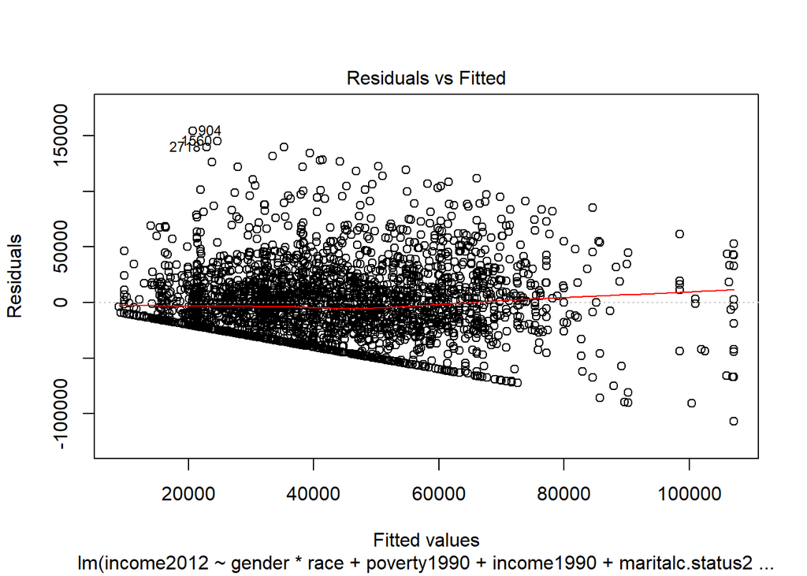

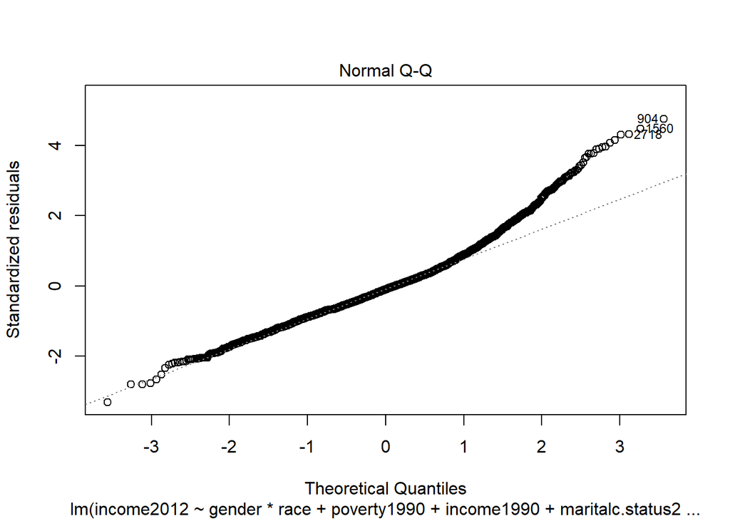

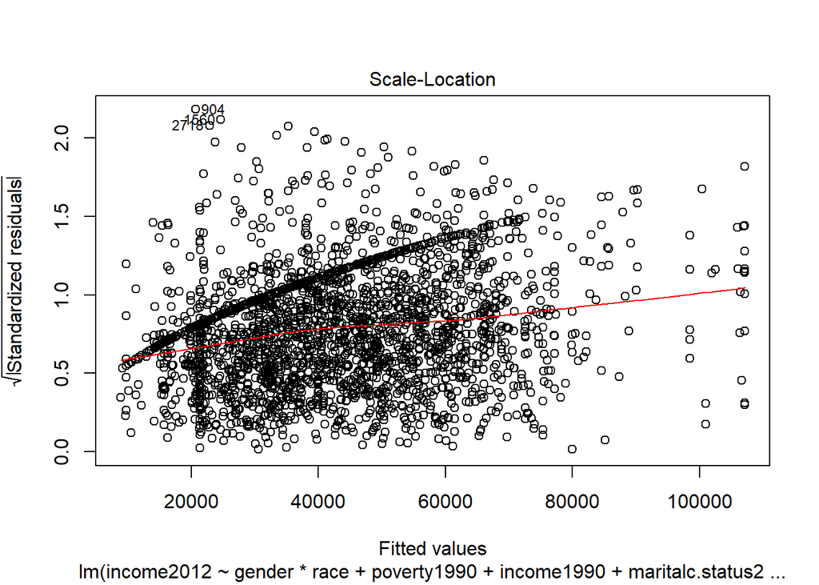

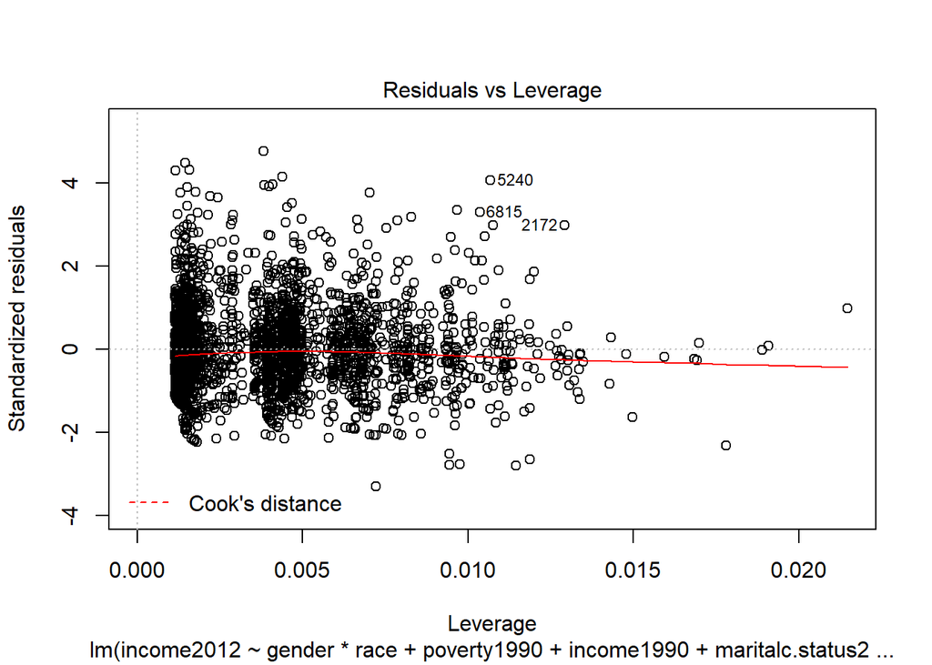

**Residuals vs Fitted**

This plot suggests non-linearity. There is a straight downward sloping line, which is expected because there is no negative income. Variance appears to increase with fitted values.

**Normal Q-Q**

This plot appears somewhat normal, with heavy upper tail thatn what is expected under noramlity. This could be due to the non-constant variance that is present in the residuals vs fitted plot above.

**Scale Location Plot** There is an increasing trend in residual variance, which is indicated by the upward sloping red line. There is also a clear straight line of riduals which could be due to the 1990 income variable.

**Residual vs Leverage** There are no clear outliers in the upper right or lower right.

Check if this looks the same with top-coded data.

[output not shown]

This looks pretty similar to the output without top-coded data. The variables `gender`, `race` and `income1990` are significant.

**Interpretations**

### **(4)** Discussion

This project has been fun and sobering at the same time. A difference in income between men and women is observed even when you hold many other factors constant. Some factors like childhood poverty, race, and one’s early career income are associated with the widening of this gap. One potential confounding factor is the 1990 income. I had assumed that income from 1990 respresented early career income, though it is possible that for those respondents who have had the same job from 1990 to 2012, it is the same data point.

There are many limitations to this project. A log transform of the income variable could have yielded a better fitted regression. But while the regression analysis shows how gender (being female) is negatively associated with income earnings, it does not explain why there is a difference in men and women’s income.

Overall, I do not have high confidence in my analyses. Due to time constraint, I did not have the chance to fully explore the data and try more combinations of variables for the regression model. I do not currently feel confident enough in my analysis to present it to policy makers.

### **(5)** Acknowledgement

I relied heavily on Professor Alexandra Chouldechova’s lecture notes for completing this project. In addition, I am thankful for the discussions with Kayla Reiman, who helped me figure out several debugging issues.